# Analysis Copepod Data

Kuei Yueh Ko

2017/2/27

# Set Environment

```r
workdir <- "C:\\Users\\clint\\Documents\\GitHub\\BlogDataAnalysis"
setwd(workdir)
#dir()
```

# Import Data

We import two dataset:

1. cop_density.txt
   - copepod total density (number/m^3) recorded in each station
2. copepod_composition.txt
   - frequency of each copepod specie recorded in each station.

```r
filePathData <- file.path(workdir,"Data","StatCompEcology","Copepod")

cPodDensity <- read.table(file.path(
    filePathData, "cop_density.txt"),
    header=T)

cPodCompose <- read.table(file.path(
    filePathData, "copepod_composition.txt"),
    header=T)
```

# Data Analysis

There are three questions, listed as below

1. Calculate the copepod density for each species for each cruise-station
2. For each cruise-station, calculate the species richness (number of species) and Shannon diversity index
3. Find dominant species (species >=2% of total composition in any cruise-station) and calculate the average density for the spring, summer, and winter cruise for each dominant species.

below are the codes I implemented to solve the questions:

### 1. Calculate the copepod density for each species for each cruise-station

For each station, since we have density of total copepod and frequency of each copepod specie, we can calculate the density of each specie simply by multiple the density(number/m^3) with frequency(%)

```r
dat   <- cPodCompose / 100 # convert to frequency
res01 <- apply(dat, 1, function(x){x * cPodDensity[,1]})
res01 <- t(res01)
```

observe the result for question 01

```r
print(res01[1:6,1:6])
```

```
##      p1 p3 p4 p6 p13    p16
## [1,]  0  0  0  0   0 0.0000
## [2,]  0  0  0  0   0 0.0000
## [3,]  0  0  0  0   0 4.6706
## [4,]  0  0  0  0   0 0.0000
## [5,]  0  0  0  0   0 0.0000
## [6,]  0  0  0  0   0 0.0000
```

### 2. For each cruise-station, calculate the species richness (number of species) and Shannon diversity index

Define helper function

```r
isZero <- function(x, threshold = 10^(-10)){
    # The function returns whether the value is zero
    # However, since we are dealing with floating number
    # it would be saver if we set the threshold to
    # determine whether the value is zero
    return((-threshold < x) & (x < threshold))
} # end func isZero
```

The Shannon’s diversity index is the application of Shannon entropy in Ecology to indicate the diversity of species in an environment. Note that values that are zero should be eliminate because log(zero) return NA

Define p as the frequency of a specie, we have the formula $\text{Shannon Entropy} = - \sum p * ln(p)$

```r
dat   <- cPodCompose / 100   # convert to frequency
res02 <- apply(dat, 2,
    function(x){
        y <- x[!isZero(x)]         # remove zero
        s <- -crossprod(y, log(y)) # -1 * sum{ p * ln(p) }
        return(s)
    } # end apply func
) # end apply
```

observe the result of all Shannon entropy for each stations (Note that there are totally 34 stations)

```r
print(res02)
```

```
##       p1       p3       p4       p6      p13      p16      p19      p21
## 1.080782 1.256126 1.045406 1.114551 2.144528 1.413396 2.582107 1.566761
##      p23      p25      s18      s19      s20      s22      s23      s25
## 2.994586 2.484830 2.841237 2.983345 2.568974 2.567104 2.878602 3.000568
##      s27      s29       sA       sB       sC       sD       sE       sF
## 2.802674 2.118423 3.106234 2.983319 2.815962 2.937975 3.020831 2.890280
##       sG      w22      w23      w25      w27      w29       wA       wB
## 1.692271 1.978899 1.615811 1.841939 2.579666 2.358688 2.613131 2.999801
##       wC       wD
## 3.213878 3.005535
```

### 3. Find dominant species (species >=2% of total composition in any cruise-station) and calculate the average density for the spring, summer, and winter cruise for each dominant species.

Helper Function

```r
plotMatrix <- function(dat, isXlab=T, isYlab=T){
    # given a data (matrix or dataframe), plot the
    # value of each element as color
    # ---------------------------------
    # Set color scale
    colPalette.WR <- colorRampPalette(c(
        "#fef0d9", "#fdbb84", "#fc8d59", "#e34a33"))(256)

    # Flipping the matrix
    mat <- as.matrix(dat)
    mat <- t(mat)
    mat <- mat[,ncol(mat):1,drop=FALSE]

    # Plot the matrix
    image(mat, xaxt= "n", yaxt= "n",
          col = colPalette.WR)

    # Show ticks if needed
    if(isXlab){ # if X ticks are added
        axis(1, at=seq(0,1,length.out=ncol(dat)),
             labels=colnames(dat), las=1)
    } # end if
    if(isYlab){ # if Y ticks are added
        axis(2, at=seq(0,1,length.out=nrow(dat)),
             labels=rev(rownames(dat)), las=2)
    } # end if
} # end func plotMatrix
```

create the weather factor: mapping stations to the corresponding weather

```r
weather <-
    ifelse(grepl("p", colnames(dat)),1,0) +
    ifelse(grepl("s", colnames(dat)),2,0) +
    ifelse(grepl("w", colnames(dat)),3,0)
weather <- factor(
    weather,
    levels=1:3,
    labels=c("Spring", "Summer", "Winter"))
```

The main goal in question 3 is to find dominant species and calculate the average density.

```r
dat <- cPodCompose
```

lets Visualize dominant species (>= 2%) in each station

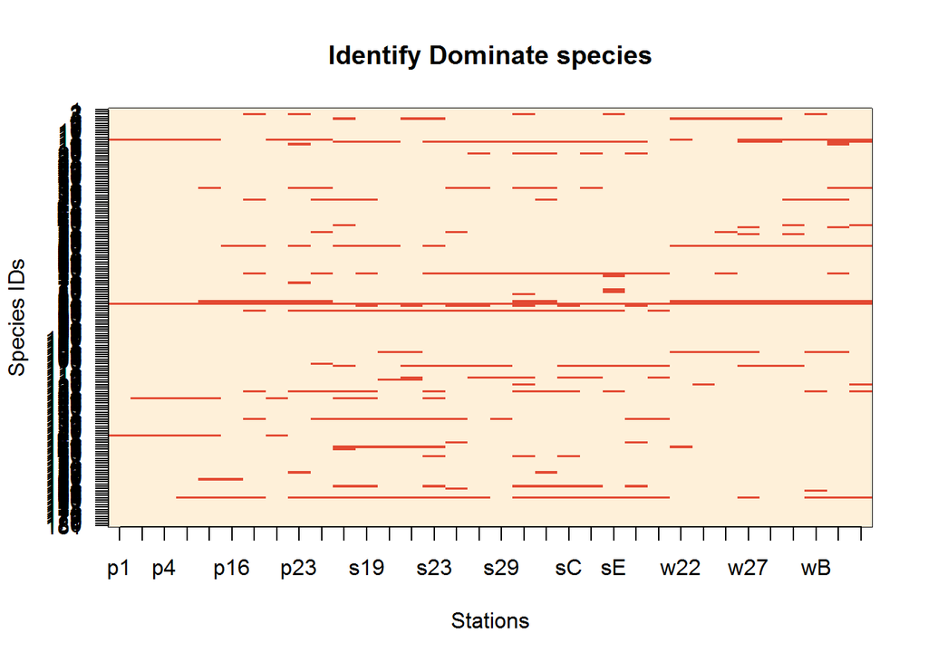

```r
res <- dat >= 2              # find dominant species
rownames(res) <- 1:nrow(res) # Set Species ID
isDominant <- res            # Store the result as isDominant
plotMatrix(isDominant)       # Visualize
title(
    main="Identify Dominate species",
    xlab="Stations",
    ylab="Species IDs")
```

To get the average density of dominant species for different weather. We will first find the dominant species

```r
# Check is any specie is dominant in any station
res <- apply(isDominant, 1, sum)
res <- res[!isZero(res)]

# get those specie IDs
species <- as.numeric(names(res))
print(species)
```

```
##  [1]   3   5  14  15  16  20  35  40  51  52  54  55  60  72  73  76  79
## [18]  80  81  84  85  86  88 106 111 112 117 118 120 123 126 135 142 145
## [35] 147 148 151 158 161 164 165 166 169
```

Next we will calculate the average density for each specie from the stations, for each weather: $\frac{\text{sum of density of the stations}}{\text{number of stations}}$

```r
res <- apply(res01, 1, function(x){
    return(tapply(x,weather,mean))
})
res03 <- res[,species]
colnames(res03) <- species
```

Visualize the result

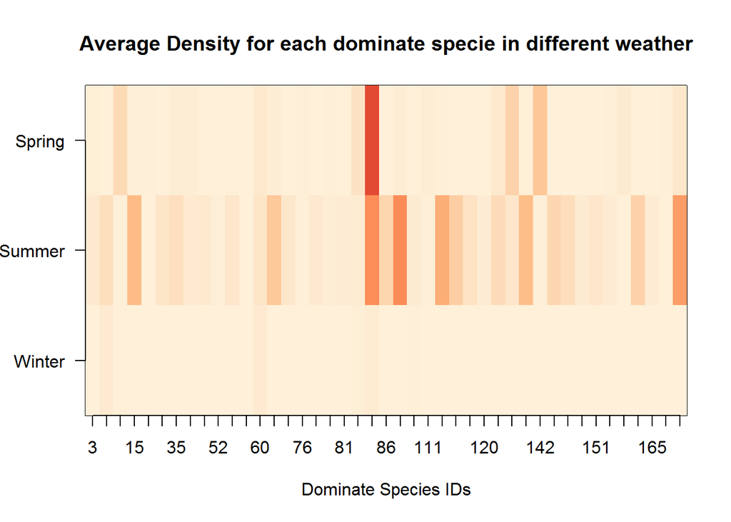

```r
plotMatrix(res03)
title(
    main="Average Density for each dominate specie in different weather",
    xlab="Dominate Species IDs")
```